# 7. Inverse probability weighting and meta analysis

2023-03-12

> [*Back to content page*](https://flatter11.github.io/r.studio/)

Learning objectives

- Appreciate the use of **inverse probability weighting**
- Apply inverse probability weighting for analysis of **missing data**
- Perform **meta analysis** to obtain overall estimate of an intervention effect from multiple studies

# 1 Inverse probability weighting

## Missing data

- Potential reasons for missing data: dropout, incomplete response, censored
- Types of missing data
  1. **Missing completely at random (MCAR)** – missingness independent of all variables  
     e.g. Accidental loss of data
  2. **Missing at random (MAR)** – missingness dependent on observed variables  
     e.g. Loss of contact of recovered patients
  3. **Missing not at random (MNAR)** – missingness dependent on unobserved variables  
     e.g. Patients with treatment failure less likely to respond
- Methods to handle missing data
  - Valid for MCAR
    1. Complete case analysis…Only analyze cases with **complete data**
       - May lose substantial information
    2. Nearest neighbour imputation…Impute missing value from **most similar subject**
    3. Mean imputation…Impute missing values by the **mean** of the variable
       - Reduces variation in the data
       - May not maintain associations between variables
  - Valid for MAR
    1. Regression imputation…Predict missing value from **regression models** (linear regression or other GLM)
    2. Multiple imputation (will be covered in CMED6040)…Single imputation treats imputed values as actual responses
       - Multiple imputation accounts for variability/uncertainty in the imputed data
    3. Inverse probability weighting…Estimate the **probability of response** based on some external knowledge
       - Weight the observed data using the inverse probability

**Example: BMI**

- Suppose we want to estimate the mean BMI in the population
- Suppose we have a target population where
  - Male has a uniformly distributed BMI from 25 to 40 kg/m<sup>2</sup>
  - Female has a uniformly distributed BMI from 15 to 30 kg/m<sup>2</sup>
  - We randomly recruited a sample of 500 persons for each sex
  - The true mean BMI is (40+25+15+30)/4 = 27.5 kg/m<sup>2</sup>
  - From previous experience, 80% of the female will not report their BMI, but all male are willing to report their BMI => **Missing at random**
- How should we estimate the mean BMI based on the observed sample?

### 1.1 Simulate dataset

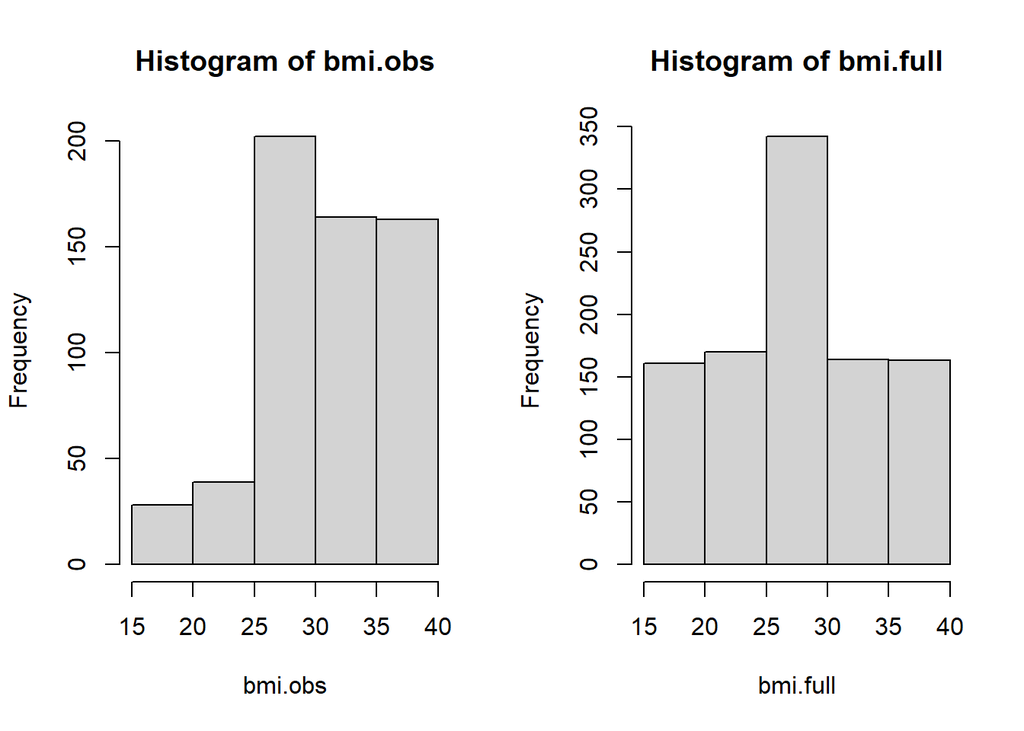

```r
###Simulate dataset with missing value
set.seed(123) #unify our results
n=500
bmi.m <- runif(n, 25, 40) #M unif distribution
bmi.f <- runif(n, 15, 30) #F unif distribution
bmi.full <- cbind(bmi.m, bmi.f) ##dataset without missing value
pi <- rep(c(1, 0.2), each=n) #NOTE the use of "each"; prob of observed for M and F
obs <- rbinom(2*n, 1, pi)
bmi.obs <- bmi.full[obs==1] ##dataset with missing value

###Visualize the dataset
par(mfrow=c(1,2))
hist(bmi.obs, breaks=c(15,20,25,30,35,40))
hist(bmi.full, breaks=c(15,20,25,30,35,40))
#The observed data has a very different BMI distribution due to missing response from female
```

### 1.2 Inverse probability weighting

- Apply a weighting which is the **inverse of the probability π of being observed**  
  E.g. A sample has a probability of 20% being observed => weight = 1/20% = 5
  - Specify π as a function of X (i.e. π(X, θ)) (X is other predictor like age of sex)

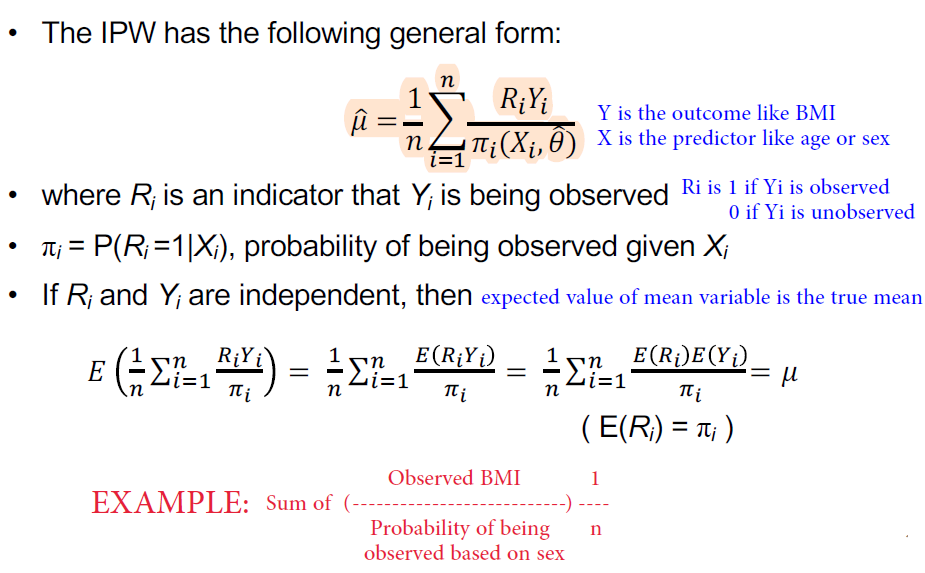

```r
mean(bmi.obs) #This estimate (complete case analysis) is biased due to missing value

pi.obs <- pi[obs==1] #The probability of being observed for each data
sum(bmi.obs/pi.obs)/(2*n) #Apply weighting and calculate the mean
##27.1 is closer to true mean BMI than 30.8
```

```
## [1] 30.84461
## [1] 27.05842
```

### 1.3 Propensity score (inverse probability) weighting

##### Example: MI

Population: 400 men aged 40-70 admitted to hospital with suspected myocardial infarction

```r
mi <- read.csv("Folder/examplemi.csv")
#Outcome variable: 30-day mortality
#Exposure/treatment: newer clot-busting drug vs standard therapy
##Confounders: age, pre-existing risk factor level (0-5, 5: highest risk),
#admission severity score (0-10, 10: most severe)
ps.model <- glm(trt~age+risk+severity, data=mi, family=binomial)
mi$ps <- predict(ps.model, type="response")
```

**Counterfactuals**: What would have happened if the patient received a different treatment (contrary to observed treatment taken)?

- Propensity score **p** as the probability of being ‘observed’ receiving newer treatment
- **1-p** as the probability of being ‘observed’ receiving standard therapy

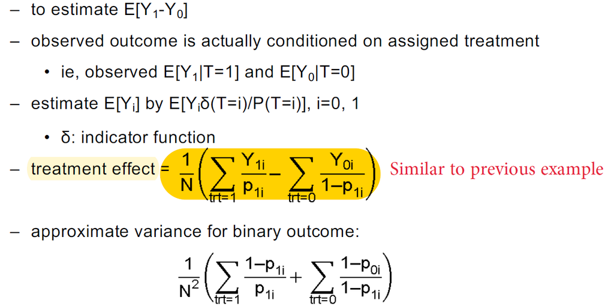

```r
with(mi, (sum(death[trt==1]/ps[trt==1]) - sum(death[trt==0]/(1-ps)[trt==0]))/400)
with(mi, sum(death/ps*(trt==1) - death/(1-ps)*(trt==0)))/nrow(mi)
#NOTE: "*(trt==1)" = those treatment not equal to 1 will become 0
##Estimated effect for clot-busting therapy: -0.065 (-0.163, 0.033)
```

```
## [1] -0.06516998
## [1] -0.06516998
```

# 2 Meta analysis

##### Example: e-cigarrette

- Aim: assess the association between e-cigarette use and cigarette smoking cessation among adult smokers interested in quitting smoking
- 7 previous studies in 2013-2015. Reported adjusted ORs and their 95% CI
- Data: extracted from Kalkhoran et al., Lancet Respir Med, 2016

```r
ecig <- read.csv("Folder/exampleecig.csv") #OR.lb and OR.ub = lower and upper bound

# Convert OR to log OR (so that it's normal)
ecig$logOR <- log(ecig$OR)
# Derive the standard error for log OR from the 95% CI
ecig$se.logOR <- (log(ecig$OR.ub)-log(ecig$OR.lb))/(2*1.96)
```

## 2.1 Heterogeneity and models

1. Clinical diversity…Variability in participants, interventions and outcomes
   - E.g. different age groups
2. Methodological diversity…Variability in study design and risk of bias
   - E.g. RCT vs cohort study
3. **Statistical heterogeneity**…Variability in the intervention effects across studies
   - Violate the assumption for fixed effects model
   - Random effects model allows the true effect to be different across studies

Clinical / methodological diversity should be addressed in the systematic review (i.e. write it down in summary table (main text or appendix). Focus on statistical heterogeneity in the following slides.

- Metrics to measure heterogeneity
  1. **Cochran’s Q test**  
     $Q = \sum_{i}w_{i}(Y_{i}-\hat{\theta})^{2}\sim X^{2}$
     - H<sub>0</sub>: no heterogeneity among studies (accept or reject based on p-val)
     - Q depends on no. of studies
  2. **Higgins’ I<sup>2</sup>**  
     $I^2 = (Q – df)/Q \times 100$
     - df = no. of studies - 1
     - Higher I2 = higher heterogeneity
     - Rule of thumb: low: 0-30%, moderate: 30-60%, substantial: 50-90%
- 2 models
  1. **Fixed effects model**  
     Assuming true effect of intervention is the same across studies
  2. **Random effects model**  
     Assuming the true intervention effect of each study comes from a larger population (subset of a larger population)

**Fixed effect model**

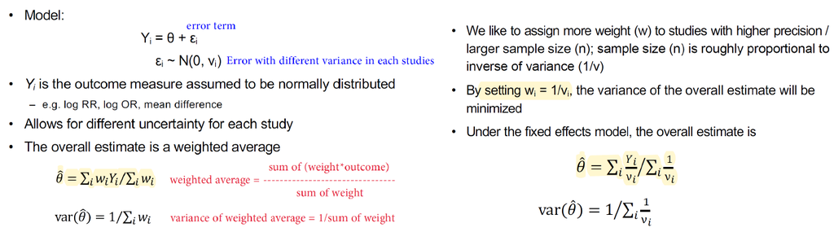

**Random effect model**

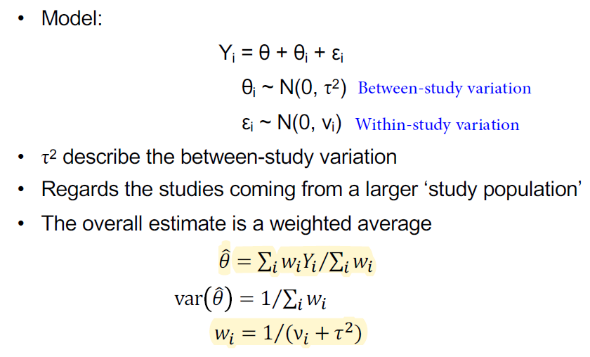

### A. Fixed effects model

- `rma(yi, vi, sei, data, method=“REML”, slab …)` (in package: metafor)
  - **yi** outcome measures or effect size
  - **vi** **sei** corresponding sampling variance or standard error (either one)
  - **data** specifies the data frame
  - **method** “FE” for fixed effects model, “REML” for random effects model (default)
  - **slab** study label

```r
## Carry out meta analysis using fixed effects model
require(metafor)
ecig.fe <- rma(yi=logOR, sei=se.logOR, slab=study, method="FE", data=ecig)
with(ecig.fe, exp(c(b, ci.lb, ci.ub))) #estimate, lower, upper bound
#The overall estimate is 0.77 (95% CI = 0.69-0.87)

## Test for heterogeniety
summary(ecig.fe) #Q p-val <0.05 --> reject no heterogeneity
Q <- ecig.fe$QE
I2 <- (Q-(ecig.fe$k-1))/Q * 100 #I^2 = 88% --> heterogeneity
I2
```

```
## [1] 0.774310 0.689606 0.869418
##
## Fixed-Effects Model (k = 7)
##
##   logLik  deviance       AIC       BIC      AICc
## -19.9293   51.3890   41.8585   41.8044   42.6585
##
## I^2 (total heterogeneity / total variability):   88.32%
## H^2 (total variability / sampling variability):  8.56
##
## Test for Heterogeneity:
## Q(df = 6) = 51.3890, p-val < .0001
##
## Model Results:
##
## estimate      se     zval    pval    ci.lb    ci.ub
##  -0.2558  0.0591  -4.3273  <.0001  -0.3716  -0.1399  ***
##
## ---
## Signif. codes:  0 '***' 0.001 '**' 0.01 '*' 0.05 '.' 0.1 ' ' 1
##
## [1] 88.32436
```

### B. Random effects model

```r
## Carry out meta analysis using random effects model
ecig.re <- rma(yi=logOR, sei=se.logOR, slab=study, data=ecig)
with(ecig.re, exp(c(b, ci.lb, ci.ub)))
```

```
## [1] 0.8589488 0.5961948 1.2375035
```

```r
#The overall estimate is 0.86 (95% CI = 0.60-1.24)
#Include uncertainty in random effect model --> wider CI compared to FE
```

## 2.2 Forest plot

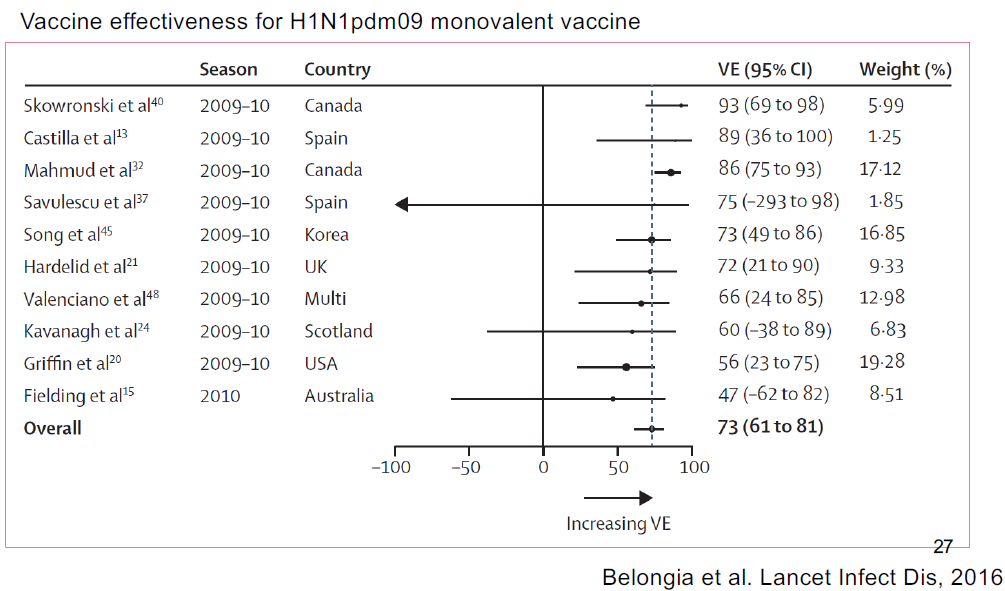

- `forest(x, showweights=FALSE, transf, refline=0, order, …)` (in package: metafor)
  - **x** an “rma” object obtained by FE/RE model
  - **showweights** TRUE (default) to show the weighting for each study
  - **transf=exp** to take exponential transformation for the outcome measure
  - **refline** specifies the reference line (0/1 depending on outcome measure)
  - **order** specifies order in effect size: “obs”; sampling variance: “prec”

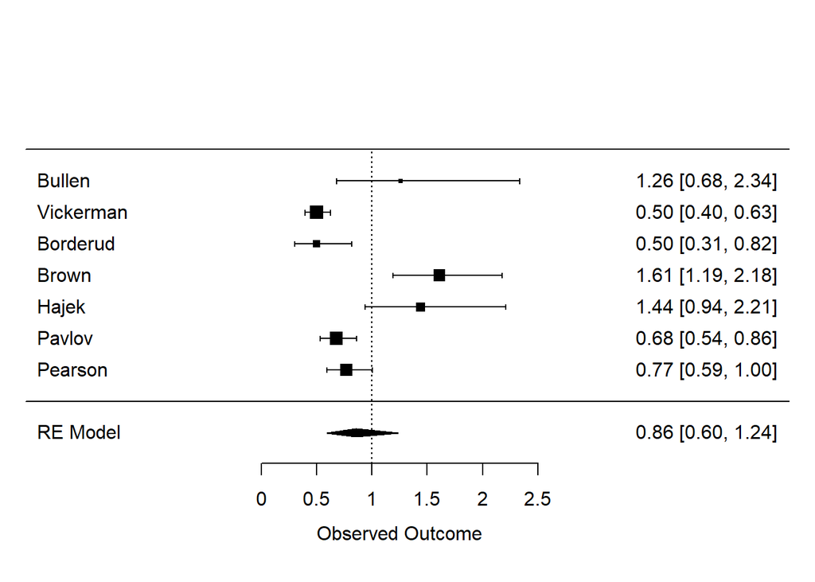

```r
## Forest plot
par(mfrow=c(1,1))
forest(ecig.re, transf=exp, refline=1)
```

```r
# No evidence that e-cigarette use is helpful to smoking cessation
# But large heterogeneity (some study less than 1, some greater than 1)
```

## 2.3 Funnel plot

**Symmetrical funnel plot**

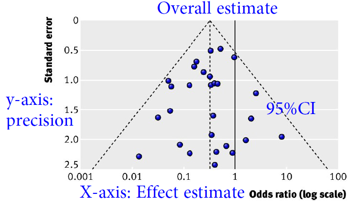

- A symmetric inverted funnel shape is expected if studies are of **good methodological quality and no reporting bias exists**
  - Larger studies likely to be near the top and closer to center line (high precision, low SE)
  - Less useful for **small no. of studies**
- Asymmetry may arise from multiple reasons:
  1. Reporting biases
  2. Poor methodological quality
  3. True heterogeneity
  4. Due to Chance
- Scatter plot of the effect estimates (X) versus precision (Y)
  - Vertical dotted line: overall estimate; diagonal: 95% CI
- `funnel(x, yaxis=“sei”, atransf, refline…)` (in package: metafor)
  - **x** an “rma” object
  - **yaxis** specifies what is shown on the y-axis. “sei” for standard error, “vi” for variance, “ni” for sample size
  - **atransf=exp** to take exponential transformation for x-axis (outcome measure)
  - **refline** specifies the reference line

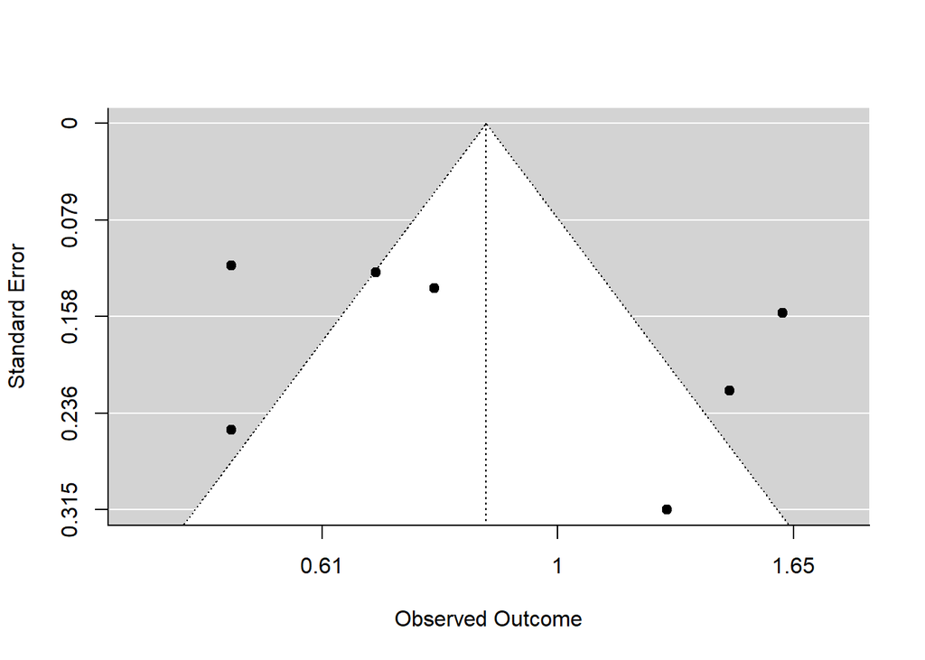

```r
## Funnel plot
funnel(ecig.re, atransf=exp)
```

```r
#Not obvious asymmetry
#Large heterogeneity (can see dots around)
```

### Test of asymmetry in the funnel plot

- Egger’s test
  - `regtest()` in package metafor
  - Low power with small number of studies (e.g. n < 10)
- Other tests: Begg’s test, Harbord’s test
- Specify the test before analysis

```r
regtest(ecig.re)
```

```
##
## Regression Test for Funnel Plot Asymmetry
##
## Model:     mixed-effects meta-regression model
## Predictor: standard error
##
## Test for Funnel Plot Asymmetry: z = 0.7469, p = 0.4552
## Limit Estimate (as sei -> 0):   b = -0.5339 (CI: -1.6063, 0.5385)
```

```r
#p-val= 0.4552 => no strong evidence of asymmetry (but bear in mind it's **small sample size**)
```

## Remarks

- rma in R can also handle some type of original data (e.g. 2 x 2 table frequencies, observed no. of outcomes, etc)
  - All can be transformed into effect size and corresponding variances (to fulfill normal assumptions(?))
- Higher heterogeneity => do **Meta-regression**
  - Allow for potential moderator on the study effect size
  - R: can be specified in the **‘mod’ option** in `rma()` function (can put predictors/variable inside to see which one is causing heterogeneity)
- In the presence of reporting bias => **Trim and fill** (see tutorial 3)
  - Estimate the overall effect by filling the ‘missing’ studies
  - As a sensitivity analysis

Summary

- To obtain an overall estimates of an intervention from studies with similar interventions and outcomes
- Give higher weighting to studies with higher precision
- Need to assess study heterogeneity
- Refer to PRISMA / MOOSE for guidelines